# Can the adaptive responses to IV BCG be predicted from baseline or early-BCG gene expression in whole-blood?

## Data

This TB Hackday script uses (pre-processed) RNA sequencing data from Liu et al. and immune response data from Darrah et al. for NHP that were immunized using IV BCG:

1. [Liu et al. 2023](https://pubmed.ncbi.nlm.nih.gov/37390827/) (*Cell Rep Med*) **Blood transcriptional correlates of BCG-induced protection against tuberculosis in rhesus macaques**
2. [Darrah et al. 2023](https://pubmed.ncbi.nlm.nih.gov/37267955/) (Cell Host Microbe) **Airway T cells are a correlate of i.v. Bacille Calmette-Guerin-mediated protection against tuberculosis in rhesus macaques**

## Background

With these studies, 34 NHPs were immunized with various doses of intravenous (i.v.) BCG. The animals were challenged after 24 weeks with Mtb. The Darrah et al. study measured immune responses from the animals after BCG and recorded challenge outcomes. The Liu et al. study conducted whole-blood RNA sequencing on samples at the pre, d2, wk2, wk4 and wk12 time points.

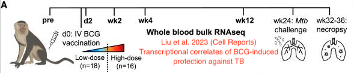

Liu et al. 2023 Cell Reports Time Points

Darrah et al. found that several immune responses measured from BAL/lung including CD4 T cells, NK cells, and PPD-specific IgA. Many of the responses co-vary, making it difficult to discern which response correlates most strongly. Liu et al. found that gene expression of specific modules *after* IV BCG were correlated with both the adaptive immune responses, as well as protection.

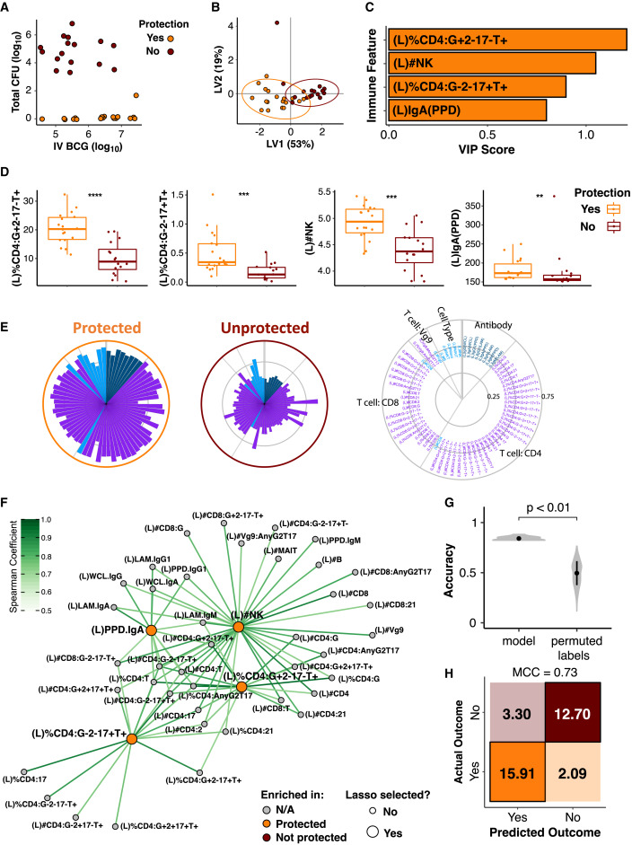

Darrah et al. 2023, Figure 6

## Hypotheses for hacking

- Are there specific pairs of immune responses or gene module scores that are significantly better at predicting the challenge outcome? Use CV-AUC to evaluate models. What model works best for combining features for prediction of outcome?
- While the original study focused on post-BCG gene expression as correlates of immune response and protection, it may be interesting to see how *baseline* gene expression is associated with immune responses or protection.
- If you use alternative outcomes, for example number of granulomas or total CFU, are there different modules or immune responses that are better associated with outcome? Are there any features that are associated consistently with all outcomes?

## Setup R and load the data.

Load relevant packages. Change `<data_dir>` variable as appropriate.

Load the immune response data, the pre-processed RNA sequencing data and the NHP meta-data. There are three important files:

```r
library(readr)
library(ggplot2)
library(dplyr)
library(tidyverse)
library(ggplot2)
library(stats)
library(multcomp) # For FDR adjustment

# NOTE --- REPLACE the <data_dir> FOLDER DESTINTATION AS APPROPRIATE
# Define the project folder and file paths
data_dir <- file.path("/fh/fast/gilbert_p/fg_data", "SEATRAC", "TB_hackday_2024", "processed_data")
# data_dir <- file.path("/home/processed_data", "SEATRAC", "TB_hackday_2024", "processed_data")

meta_fn <- file.path(data_dir, "liu_etal_metadata.csv")
module_fn <- file.path(data_dir, "liu_etal_modules.csv")
cts_fn <- file.path(data_dir, "liu_etal_counts_long.csv")
immune_fn <- file.path(data_dir, "darrah_dose_immune_markers.csv")

# Load the data
meta <- readr::read_csv(meta_fn)
modules <- readr::read_csv(module_fn)
ncts <- readr::read_csv(cts_fn)

# Load immune data and rename 'subjid' to 'animalid'
imm <- readr::read_csv(immune_fn) %>%
  rename(animalid = subjid)
```

## Compute module scores and visualize BCG response

Gene modules were generated de-novo by Liu et al. using WGCNA on the genes that were differentially expressed after BCG. They detected DEGs at each time point and combined them for the WGCNA analysis. We can then compute a score for each module within each sample by averaging the expression of genes in the module.

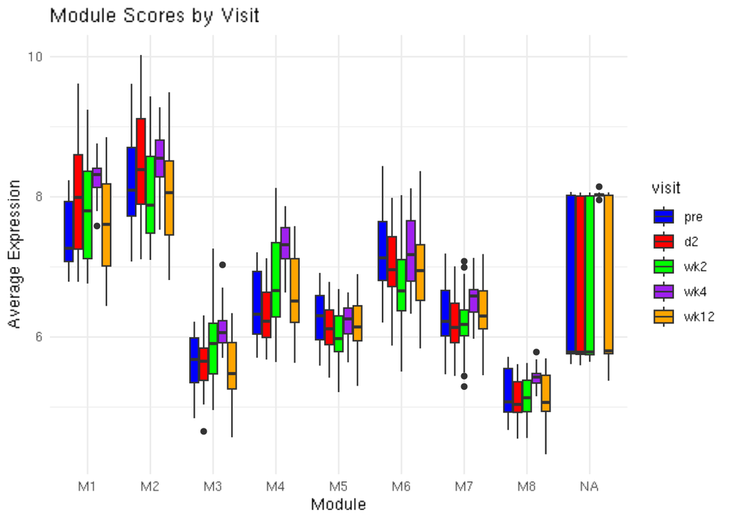

```r
# Merge module names with the gene count data
# This allows us to compute module scores for each module
ncts <- ncts %>%
  left_join(modules, by = "gene", relationship = "many-to-many")

# Compute module scores (average expression of genes in each module using log2-counts)
mod_scores <- ncts %>%
  group_by(sampleid, module) %>%
  summarise(count = mean(count, na.rm = TRUE), .groups = "drop") %>%
  left_join(meta, by = "sampleid")

mod_scores <- mod_scores %>%
  mutate(visit = factor(visit, levels = c("pre", "d2", "wk2", "wk4", "wk12")))

# Quick plot of module scores by visit pre/post-BCG
ggplot(mod_scores, aes(x = module, y = count, fill = visit)) +
  geom_boxplot() +
  scale_fill_manual(values = c("pre" = "blue", "d2" = "red", "wk2" = "green", "wk4" = "purple", "wk12" = "orange")) +
  labs(title = "Module Scores by Visit", x = "Module", y = "Average Expression") +
  theme_minimal()
```

## Estimate correlation of module scores with other immune responses

As an example we will focus on the M1 module which is up-regulated 2 days post-BCG. We then filter the gene expression data to just M1@d2 and join with the immune response data, careful to join on the `animalid`. Correlation is assessed using rank-based Spearman correlation. The joining and correlating is repeated for each immune response variable by doing a `group_map` over the `key` variable. Finally, results are aggregated and an adjustment for multiple hypothesis testing is applied.

```r
# Estimate how M1 module scores at day 2 correlate with various immune responses
mod <- "M1"
mod_visit <- "d2" # Options ['pre', 'd2', 'wk2', 'wk4', 'wk12']

# Filter immune response data to match module scores and calculate correlations
results <- imm %>%
  group_by(key) %>%
  group_map(~ {
    test_df <- mod_scores %>%
      filter(module == mod, visit == mod_visit) %>%
      inner_join(.x, by = "animalid") %>%
      drop_na(value, count)

    if (nrow(test_df) > 0) {
      rho <- cor(test_df$count, test_df$value, method = "spearman")
      pvalue <- cor.test(test_df$count, test_df$value, method = "spearman")$p.value
      tibble(
        module = mod,
        mod_visit = mod_visit,
        imm_key = unique(.y$key),
        n = nrow(test_df),
        rho = rho,
        pvalue = pvalue
      )
    } else {
      tibble(
        module = mod,
        mod_visit = mod_visit,
        imm_key = unique(.y$key),
        n = 0,
        rho = NA,
        pvalue = NA
      )
    }
  }) %>%
  bind_rows()

# Adjust p-values for multiple testing (FDR correction)
results <- results %>%
  mutate(fdrq = p.adjust(pvalue, method = "fdr"))

# Sort results by p-value and display the top 20
results <- results %>%
  arrange(pvalue)

# View the results
results %>%
  slice_head(n = 20)
```

[output not shown]

## Visualize a top result

Here we can visualize one of the top correlations using a scatter plot. This correlation of M1 gene expression at day 2 with CD4+ T cell responses in the blood was reported in the manuscript. From here one could consider how pairs of modules are able to predict the adaptive immune responses, or find an optimal predictor using machine learning.

It is also interesting to consider how pre-BCG gene expression predicts the adaptive response, with specific focus on the innate/inflammatory gene modules that are about to be induced by BCG.

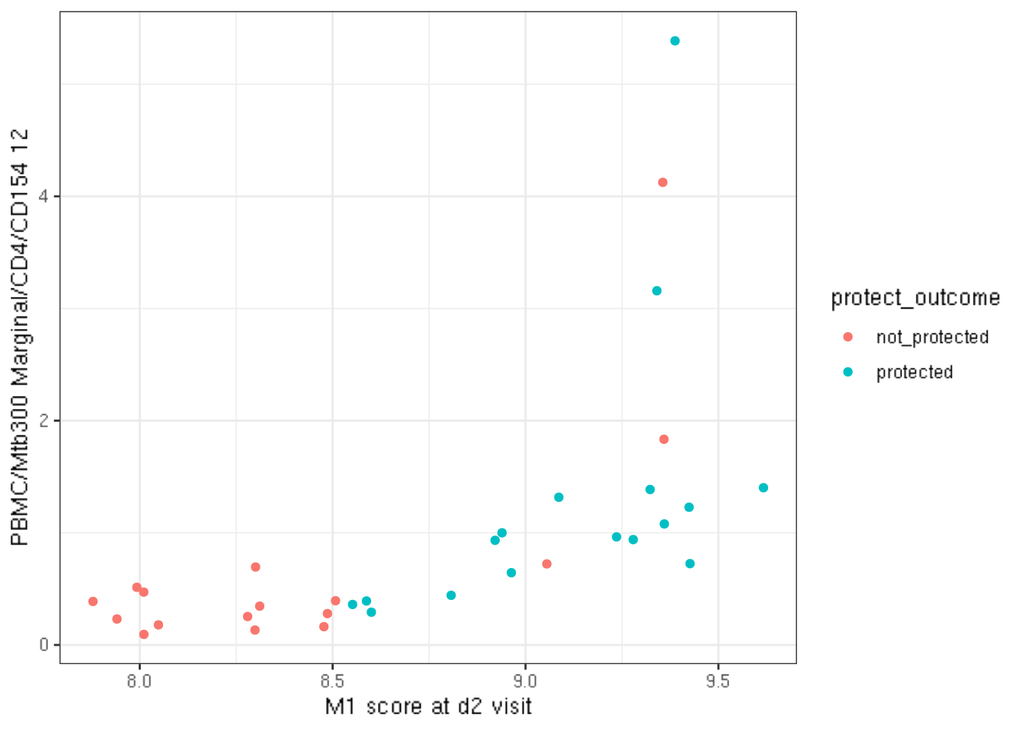

```r
# Example correlation scatter plot
mod <- "M1"
mod_visit <- "d2"
imm_key <- "PBMC/Mtb300 Marginal/CD4/CD154 12"

plot_df <- mod_scores %>%
  filter(module == mod, visit == mod_visit) %>%
  inner_join(imm %>% filter(key == imm_key), by = "animalid") %>%
  drop_na(value, count)

# Plot the data
gg = ggplot(plot_df, aes(x = count, y = value, color = protect_outcome)) +
  geom_point() +
  labs(
    x = paste(mod, "score at", mod_visit, "visit"),
    y = imm_key
  ) +
  theme_bw()
gg
```